# Доклад

Маршрутизация

Виноградова М.А.

Российский университет дружбы народов, Москва, Россия

16 ноября 2026

# Информация

## Докладчик

- Виноградова Мария Андреевна
- студентка НПИбд-02-24
- номер студ. билета 1132240691
- Российский университет дружбы народов
- 1132240691@rudn.ru
- https://github.com/mavinogradova/study_2026-2027

# Введение

## Актуальность маршрутизации

- Компьютерные сети объединяют устройства, находящиеся в разных сетях и географических точках.
- Для обмена данными необходимо определить путь от отправителя к получателю.
- Маршрутизация обеспечивает передачу IP-пакетов между сетями.

**Главная задача:** доставить пакет по подходящему маршруту.

# Понятие и назначение

## Что такое маршрутизация?

**Маршрутизация** — процесс определения пути передачи пакетов от отправителя к получателю через одну или несколько сетей.

- Основное устройство — маршрутизатор (router).
- Работает на сетевом уровне модели OSI.
- Принимает решения на основе IP-адреса назначения.

## Маршрутизатор и коммутатор

| Коммутатор | Маршрутизатор |
| --- | --- |
| Соединяет устройства в локальной сети | Соединяет разные IP-сети |
| Использует MAC-адреса | Использует IP-адреса |
| Обычно работает на канальном уровне | Работает на сетевом уровне |

# Принцип работы

## Как проходит пакет через сеть?

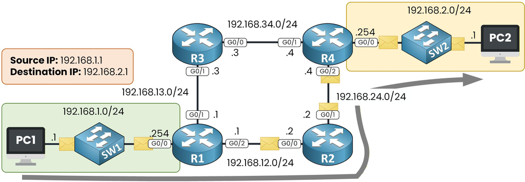

Передача IP-пакетов через несколько маршрутизаторов

1. Маршрутизатор принимает пакет.
2. Анализирует IP-адрес назначения.
3. Ищет подходящую запись в таблице маршрутизации.
4. Выбирает следующий узел или интерфейс.
5. Передает пакет дальше.

## Таблица маршрутизации

Содержит сведения, необходимые для выбора направления передачи пакета:

- сеть назначения и маска;
- следующий узел (next hop);
- выходной интерфейс;
- метрика и источник маршрута.

| Сеть назначения | Следующий узел | Интерфейс |
| --- | --- | --- |
| 192.168.1.0/24 | Напрямую | eth0 |
| 192.168.2.0/24 | 10.0.0.2 | eth1 |
| 0.0.0.0/0 | 10.0.0.1 | eth1 |

## Выбор наиболее подходящего маршрута

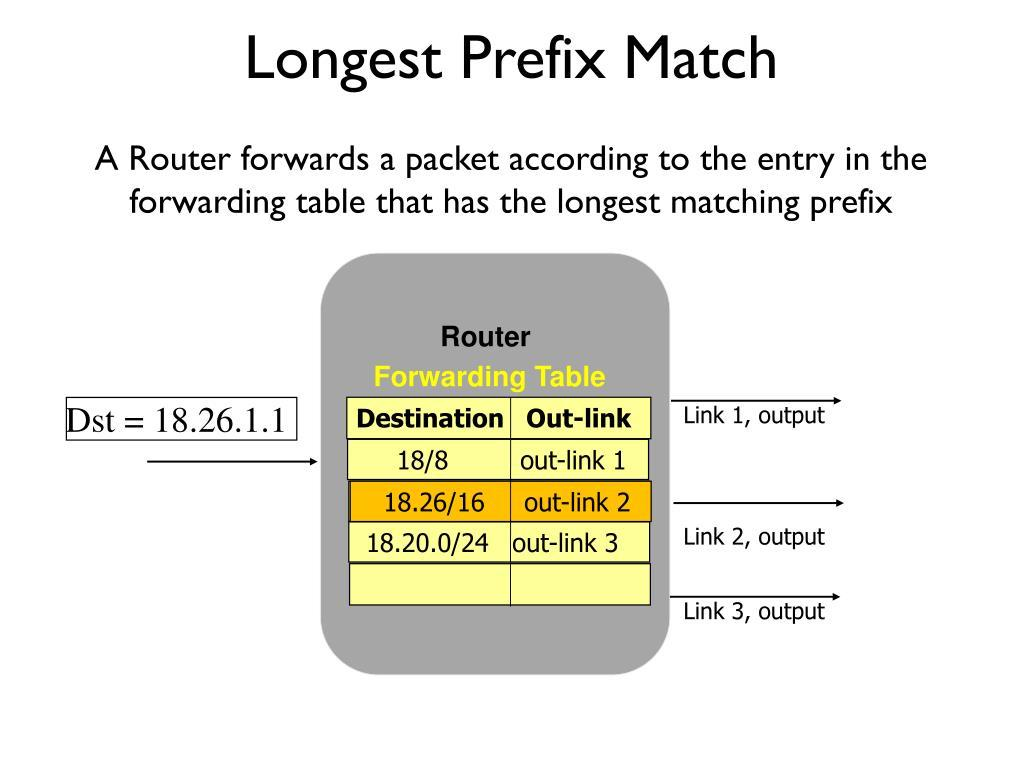

Принцип наиболее длинного совпадения префикса

**Longest Prefix Match** — выбирается маршрут с наиболее длинным совпадающим префиксом.

Например, для адреса `192.168.1.150`:

- `192.168.0.0/16`
- `192.168.1.0/24`
- `192.168.1.128/25` ← наиболее точное совпадение

Если подходящего более конкретного маршрута нет, может использоваться маршрут по умолчанию `0.0.0.0/0`.

# Виды маршрутизации

## Статическая и динамическая маршрутизация

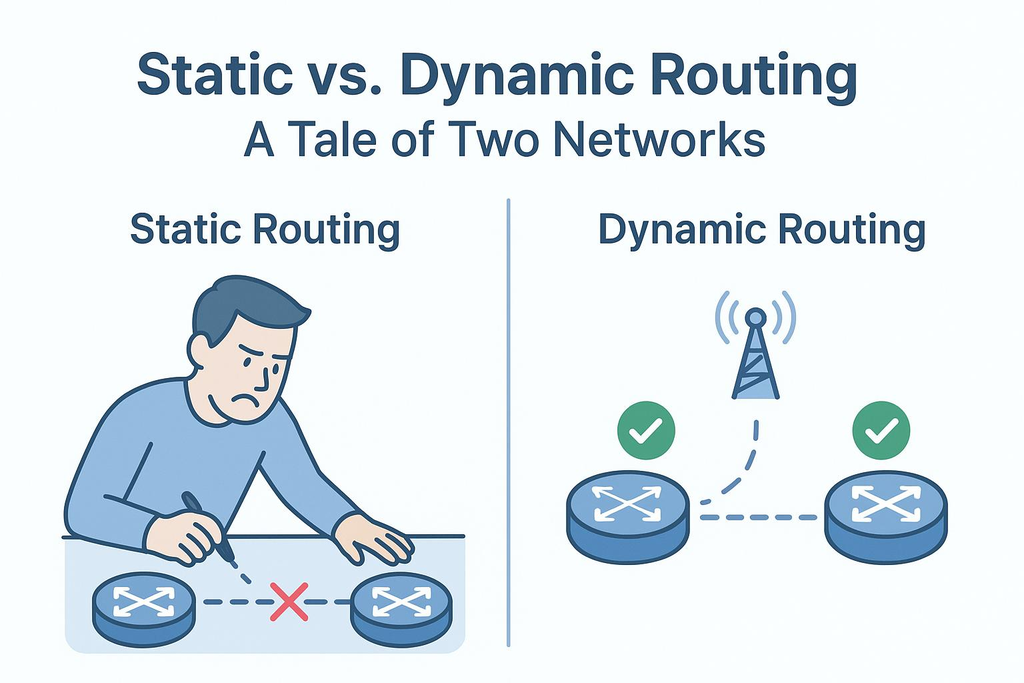

Сравнение статической и динамической маршрутизации

**Статическая:** маршруты вручную задаёт администратор.

**Динамическая:** маршрутизаторы обмениваются маршрутной информацией и обновляют таблицы автоматически.

## Сравнение способов

| Статическая | Динамическая |
| --- | --- |
| Простая для небольших сетей | Подходит для крупных сетей |
| Предсказуемые маршруты | Автоматическая адаптация |
| Нет обмена маршрутной информацией | Требует обмена служебными данными |
| Изменения выполняются вручную | Возможен выбор резервного пути |

**Сходимость** — состояние, при котором маршрутизаторы согласовали информацию о доступных сетях и маршрутах.

# Протоколы динамической маршрутизации

## RIP, OSPF и BGP

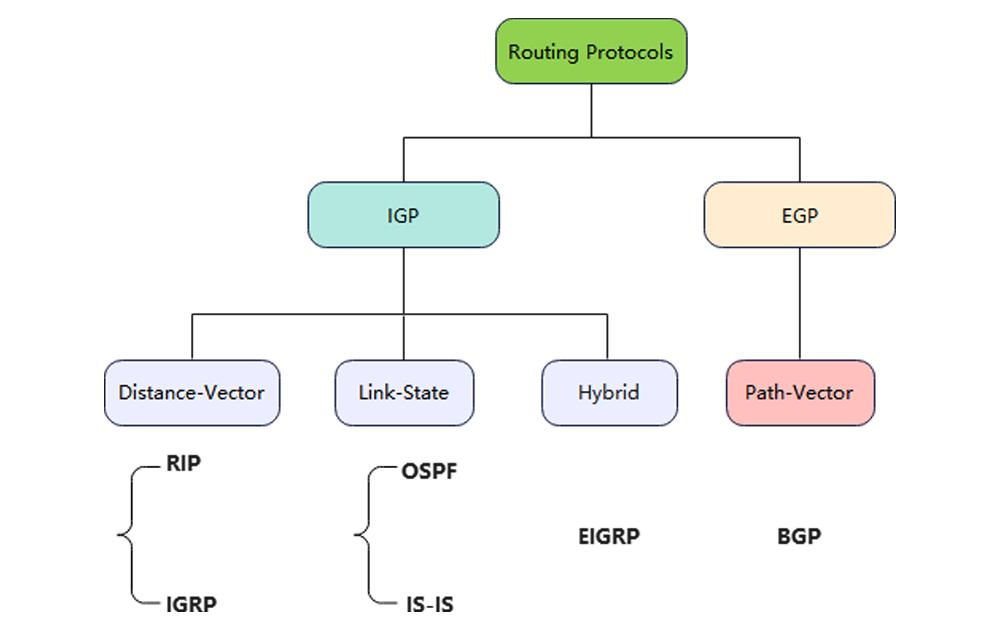

Сравнение протоколов динамической маршрутизации

- **RIP** — выбирает маршрут по количеству переходов.
- **OSPF** — рассчитывает путь по стоимости каналов внутри организации.
- **BGP** — обменивается маршрутами между автономными системами Интернета.

## Особенности RIP и OSPF

**RIP (Routing Information Protocol)** - Алгоритм вектора расстояний. - Метрика — количество переходов (hop). - Максимум — 15 переходов; 16 означает недостижимую сеть.

**OSPF (Open Shortest Path First)** - Алгоритм состояния каналов. - Использует стоимость маршрута (cost). - Для расчёта применяется алгоритм Дейкстры. - Поддерживает разделение сети на области (areas).

## Особенности BGP

**BGP (Border Gateway Protocol)** — протокол обмена маршрутами между автономными системами (AS).

- Автономная система находится под единым административным управлением.
- Учитываются атрибуты маршрута и административные политики.
- Примеры атрибутов: `AS_PATH`, `LOCAL_PREF`, `MED`.

**Роль:** обеспечивает обмен маршрутной информацией между крупными сетями и операторами Интернета.

## Сравнение протоколов

| Параметр | RIP | OSPF | BGP |
| --- | --- | --- | --- |
| Подход | Вектор расстояний | Состояние каналов | Вектор пути |
| Критерий | Число переходов | Стоимость | Политики и атрибуты |
| Применение | Небольшие сети | Внутренние сети | Между AS |
| Масштабируемость | Ограниченная | Высокая | Очень высокая |

# Алгоритмы маршрутизации

## Три основных подхода

- **Вектор расстояний:** маршрутизатор получает от соседей сведения о сетях и расстояниях до них. Пример — RIP.
- **Состояние каналов:** устройства распространяют сведения о соединениях и строят общую карту топологии. Пример — OSPF.
- **Вектор пути:** вместе с маршрутом передаётся последовательность автономных систем. Пример — BGP.

# IPv4 и IPv6

## Маршрутизация в IPv4 и IPv6

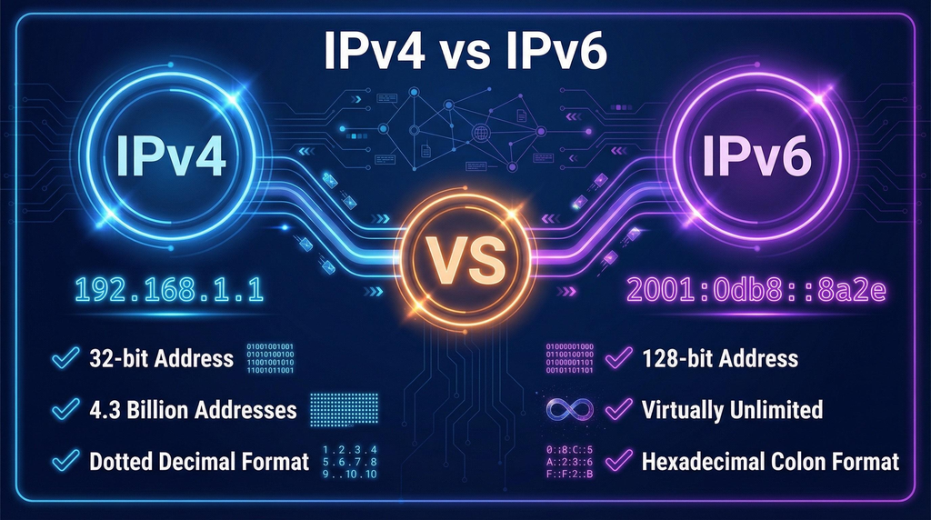

Сравнение адресации IPv4 и IPv6

Принцип маршрутизации одинаков: анализ адреса назначения и выбор следующего узла.

- **IPv4:** 32 бита, например `192.168.1.10`.
- **IPv6:** 128 бит, например `2001:db8:1::10`.
- Для IPv6 применяются специальные механизмы и протоколы, например OSPFv3.

# Практическая организация

## Команды маршрутизации в Linux

Просмотр таблицы маршрутизации:

```bash
ip route
```

Просмотр сетевых интерфейсов и адресов:

```bash
ip address
```

Добавление статического маршрута:

```bash
sudo ip route add 192.168.2.0/24 via 192.168.1.1
```

Удаление маршрута:

```bash
sudo ip route del 192.168.2.0/24
```

# Проблемы и безопасность

## Типичные проблемы

- **Маршрутные петли** — пакеты циркулируют между маршрутизаторами.
- **Отказ канала или устройства** — маршрут становится недоступен.
- **Ошибки конфигурации** — неверные адреса, маски или записи таблицы.
- **Перегрузка каналов** — растут задержки и потери пакетов.
- **Подмена маршрутов** — распространение ложной маршрутной информации.

## Как повысить надёжность и безопасность?

- Использовать резервные маршруты.
- Контролировать состояние оборудования и каналов.
- Фильтровать принимаемые и объявляемые маршруты.
- Ограничивать распространение маршрутной информации.
- Применять аутентификацию, если она поддерживается.
- Регулярно проверять конфигурацию.

# Заключение

## Основные выводы

- Маршрутизация обеспечивает передачу IP-пакетов между различными сетями.
- Маршрутизатор выбирает направление по таблице маршрутизации.
- Статические маршруты задаются вручную, динамические — обновляются протоколами.
- RIP, OSPF и BGP решают задачи маршрутизации в сетях разного масштаба.
- Надёжность сети зависит от корректной настройки, резервирования и защиты маршрутной информации.

**Маршрутизация — необходимая основа работы современных компьютерных сетей и Интернета.**